# Project 2

Benjamin Lutz

12/4/2021

## Problem 1

The first dataset (data1.txt) includes two variables, $\textit{Power_Generated}$ and $\textit{Wind_Speed}$. We want to investigate the relationship between the power generated (kwh) from wind mill turbine and the wind speed (m/s) at the time. Please fit a linear model to this data and analyze it thoroughly as you can, also answer the following questions. (50)

```r
powerData <- read.table("~/Desktop/Past_Classes/Fall_2021/Linear_Regression_Analysis/Exams/data1.txt", header = T)

y = powerData$Power_Generated
x = powerData$Wind_Speed
```

**(a)** When you fit the model, determine which variable is the response and which is regressor.

```r
linMod1 <- lm(Power_Generated ~ Wind_Speed, data = powerData)

linMod1
```

```
##
## Call:
## lm(formula = Power_Generated ~ Wind_Speed, data = powerData)
##
## Coefficients:
## (Intercept)   Wind_Speed
##     -13.600        4.663
```

Since the presence of wind determines whether power is generated, $\textit{Power_Generated}$ is the response and $\textit{Wind_Speed}$ is the regressor. Here is the fitted linear model.

$$\begin{equation*}
\hat{y} = -13.600 + 4.663x
\end{equation*}$$

**(b)** When you fit the linear model and explain the intercept and slope, please do a hypothesis testing of $\beta_0 = 0$. Discuss this result. My guess is $\beta_0 < 0$, please try to explain why my assumption makes sense. Note that both of variables are positive.

The intercept is an approximation of how much power is generated (or lost) when there is no wind, and the slope is the rate at which power generated increases as wind speed increases. It is a good guess that $\beta_0 < 0$ because it is likely that power is lost through the idling system when there is no wind.

We first conduct hypothesis tests for $\beta_1 = 0$ and $\beta_0 = 0$.

```r
summary(linMod1)
```

```
##
## Call:
## lm(formula = Power_Generated ~ Wind_Speed, data = powerData)
##
## Residuals:
##     Min      1Q  Median      3Q     Max
## -27.436  -7.127  -0.903   5.891  38.082
##
## Coefficients:
##             Estimate Std. Error t value Pr(>|t|)
## (Intercept) -13.6001     1.2600  -10.79   <2e-16 ***
## Wind_Speed    4.6632     0.1688   27.62   <2e-16 ***
## ---
## Signif. codes:  0 '***' 0.001 '**' 0.01 '*' 0.05 '.' 0.1 ' ' 1
##
## Residual standard error: 11.09 on 631 degrees of freedom
## Multiple R-squared:  0.5474, Adjusted R-squared:  0.5467
## F-statistic: 763.1 on 1 and 631 DF,  p-value: < 2.2e-16
```

For $\beta_0 = 0$ we have a p-value of $0+$, so $\beta_0 \neq 0$.

For $\beta_1 = 0$ we also have a p-value of $0+$, so $\beta_1 \neq 0$.

```r
confint(linMod1, level=0.95)
```

```
##                  2.5 %     97.5 %
## (Intercept) -16.074458 -11.125771
## Wind_Speed    4.331721   4.994699
```

A $95\%$ confidence interval on $\beta_1$ is

$$\begin{equation*}
(4.331721, 4.994699)
\end{equation*}$$

and a $95\%$ confidence interval on $\beta_0$ is

$$\begin{equation*}
(-16.074458, -11.125771)
\end{equation*}$$

The CI on $\beta_0$ indicates that your guess of $\beta_0 < 0$ is likely accurate.

**(c)** Remember to detect the model adequacy and outliers. Try to discuss the possible reasons of high influence points and outliers if you found some.

We have $\mbox{R}^2 = 0.5474$ and $\mbox{R}_{Adj}^2 = 0.5467$, so $54.7\%$ of the error is accounted for by the model.

To test for outliers, we use the studentized residuals.

```r
library(car)
summary(rstandard(linMod1))
```

```
##      Min.   1st Qu.    Median      Mean   3rd Qu.      Max.
## -2.476449 -0.643111 -0.081475  0.000245  0.533200  3.436438
```

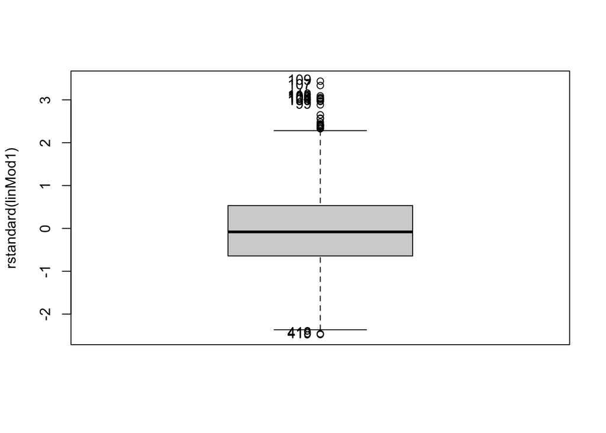

```
##  [1] 418 419 109 107 110 105 106 104 108 103 101  99
```

```r
Boxplot(rstandard(linMod1))
```

The residuals for points $418, 419, 109, 107, 110, 105, 106, 104, 108, 103, 101, 99$ are outliers. These outliers may have been caused by occasional bad readings or by windmill troubleshooting or malfunctions.

We now test the model for influence points.

```r
summary(cooks.distance(linMod1))
```

```
##      Min.   1st Qu.    Median      Mean   3rd Qu.      Max.
## 1.000e-09 9.001e-05 4.840e-04 1.429e-03 1.289e-03 2.502e-02
```

Since the largest Cooks Distance is $2.502*10^{-2} < 1$, we conclude that there are no influential points.

We examine the following plots to test model adequacy.

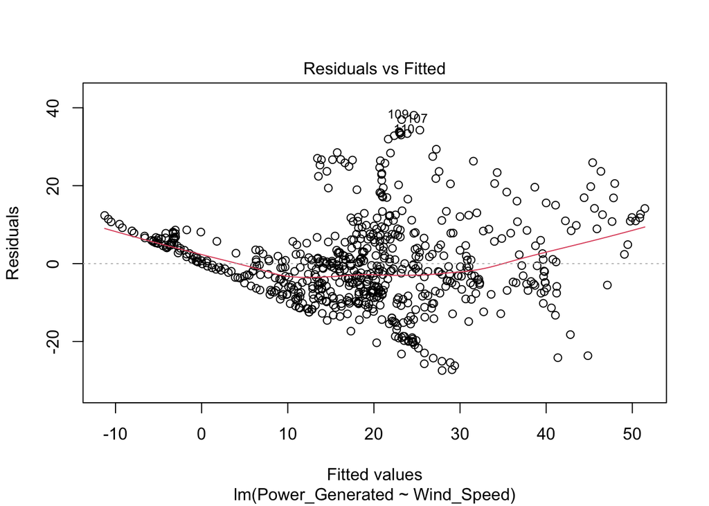

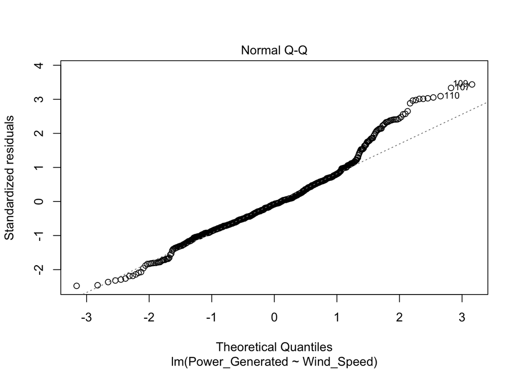

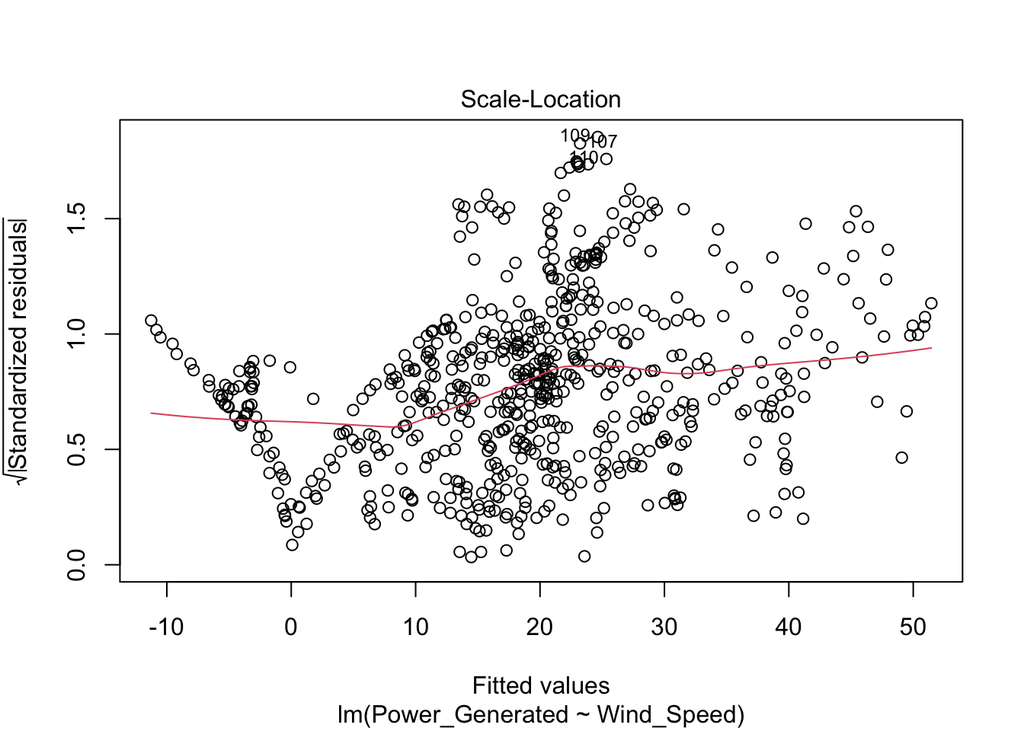

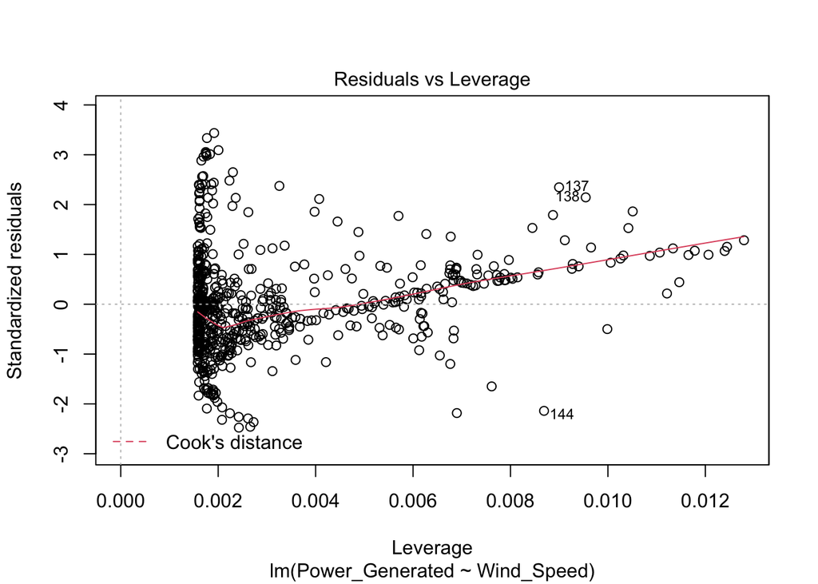

```r
plot(linMod1)
```

To potentially fix this, we can examine a plot of the response vs the regressor.

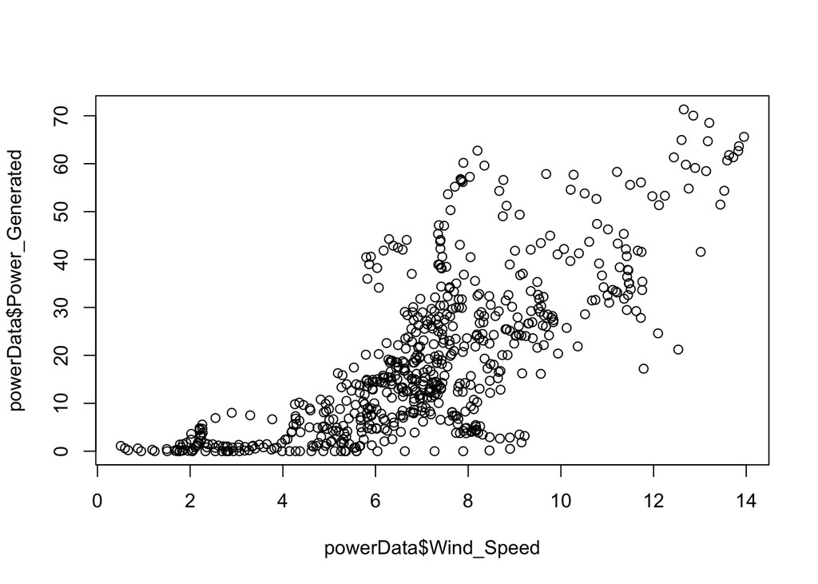

```r
plot(powerData$Wind_Speed, powerData$Power_Generated)
```

Based on this plot, it is possible that the data are exponentially related in which case a log transformation on the response would help the non constant variance of residuals.

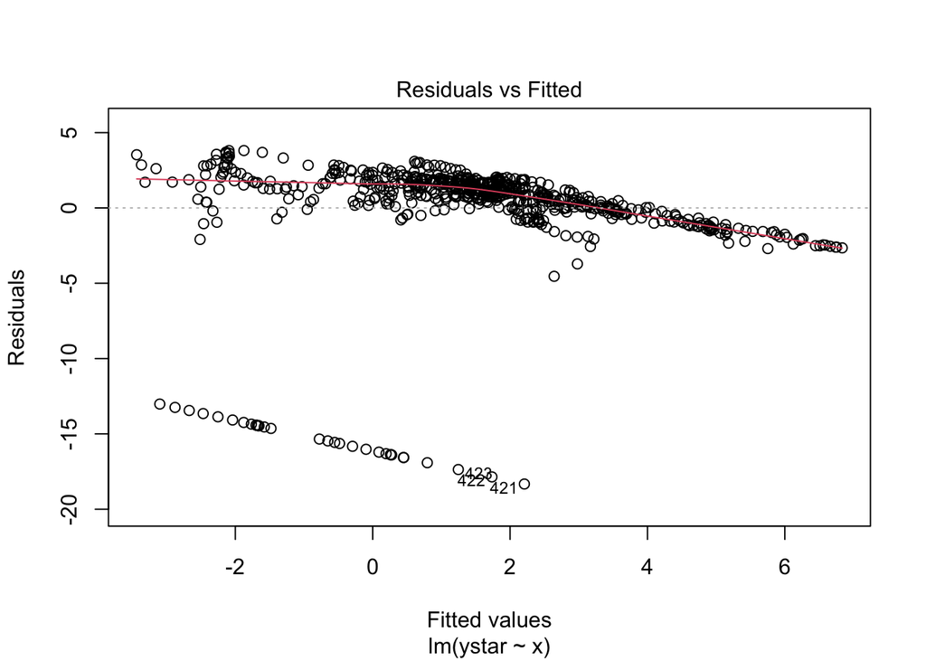

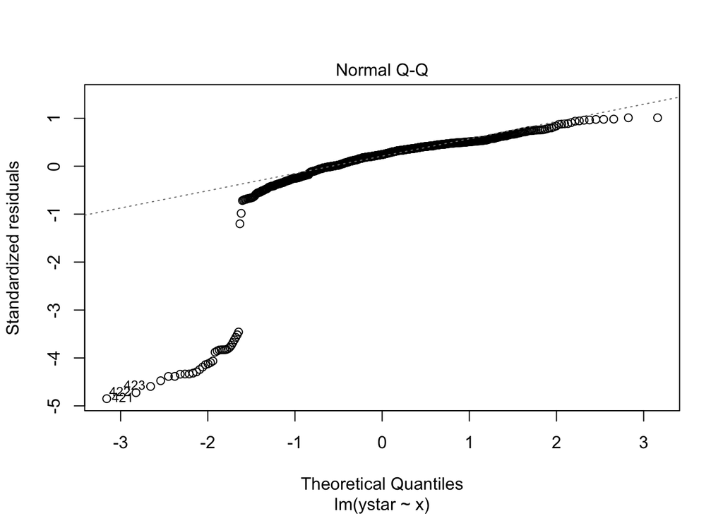

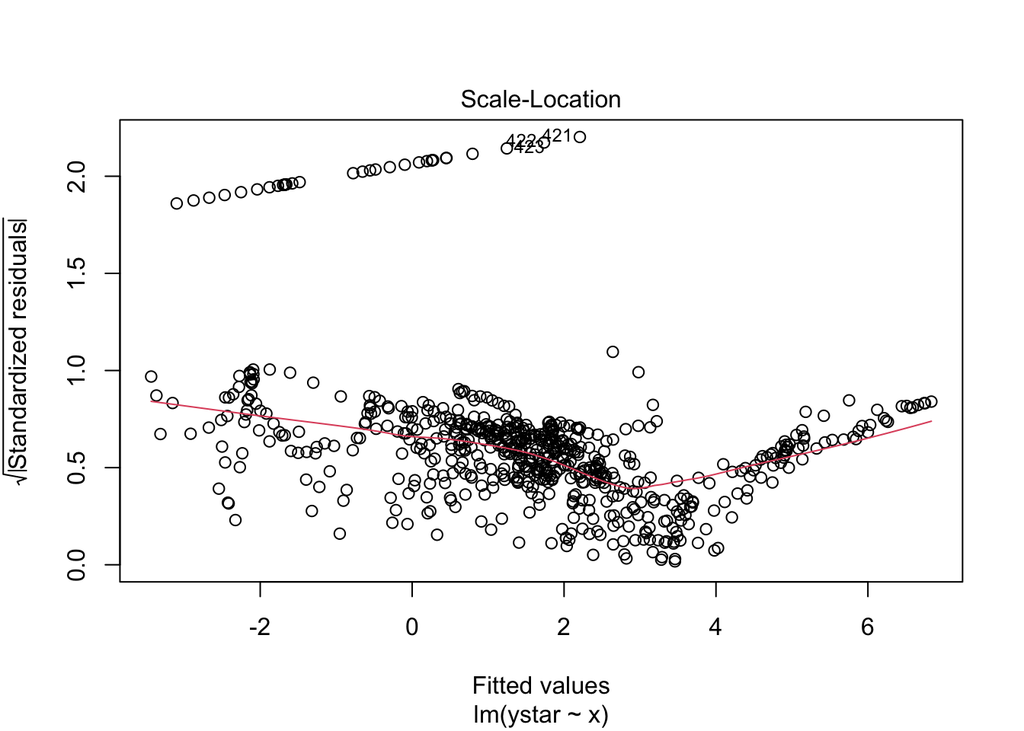

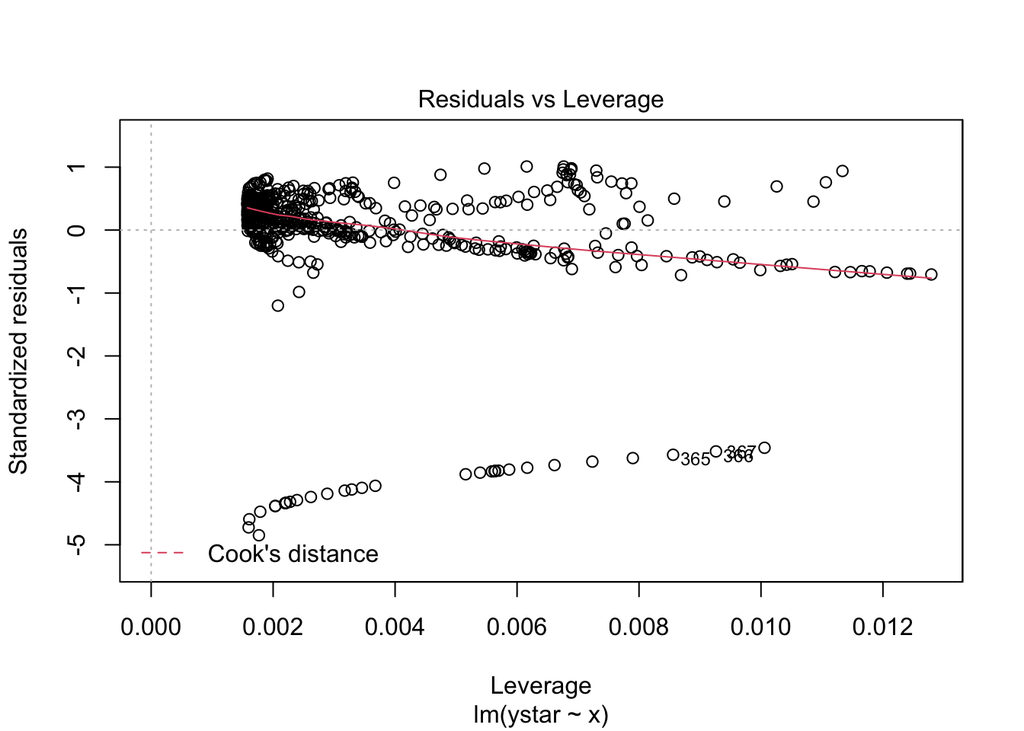

```r
#Add 0.0000001 to y to address any y=0 scenarios
linMod1$ystar = log(y+0.0000001)
ystar = linMod1$ystar

linMod1B <- lm(ystar ~ x)
plot(linMod1B)
```

**(d)** Could you extrapolate your model to a wider range of data? Explain why or why not.

The model has non constant variance and the normality assumption is violated. When model assumptions are violated, it is unsafe to extrapolate the model to a wider range of data. For our case in particular, the variance seems to grow substantially for larger fitted values, so additional terms outside the current range might have larger variance in the error terms.